# Codestellar Notebook

## Why I created this notebook?

- I needed a super simple solution to create notes
- I wanted that whatever can be useful to other devs, I should share that
- And thus I wanted to pubish the notes as a Single Page Website
- A simple git push should publish my website. Github Pages is a great way but I wanted a custom template as well.
- Wordpress, Blogger and N number of soultions are there but this attracted me.

## Getting Started

Want to own this notebook? Here are the steps

- Get your own repository [link](https://pages.github.com/)
- Download my repository
- Copy code in .github.io local repo
- Update notes.md
- Download [Pandoc](https://pandoc.org/installing.html)
- Run the command in readme.md in commandline
- Commit and Push your changes
- Yay! you own it.
- All you need to do is to update notes.md next time.

## About Me

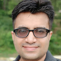

- Principal Consultant at Technossus
- 7+ years of experience in Web Application Development
- MCSD App Builder
- Open Teacher
- Learner.

# Angular Notes

## Angular NGRX

- What is **state**? What the user did? What the user sees? Some of the state we might want to save to make it persistent.
- What is the problem? Why it is so hard? Always tracking where a change happened, where the state of the application got changed.
- How we are informing? Event Emitters, Subjects to announce that ‘this’ has been changed. Well, we are doing it right.
- As your app grows, even this service driven subjects may be hard to maintain.
- So, we want to have 1 central place to maintain application state. Single Source of Truth.
- How do we change the state? REDUX PATTERN ** Actions - Dispatch action and sent to. e.g. SAVE ** Reducer - Take the payload as input and override the state i.e. immutable. ** Store - Which is containing the state.

So, we are achieving this in Angular using ngrx.